# IC Case 31: Summary of Data Analysis

R3, R6, and R4

Author

Wenting Jiang

Published

November 19, 2026

# R3: Employee proficiency

R3 asks: *What are members’ attitudes and beliefs about the proficiency of credit union employees?*

## Descriptive statistics

Table 1: Employee proficiency composite

| N | Mean | SD | Median | Minimum | Maximum |
| --- | --- | --- | --- | --- | --- |
| 128 | 4.21 | 0.59 | 4 | 2.75 | 5 |

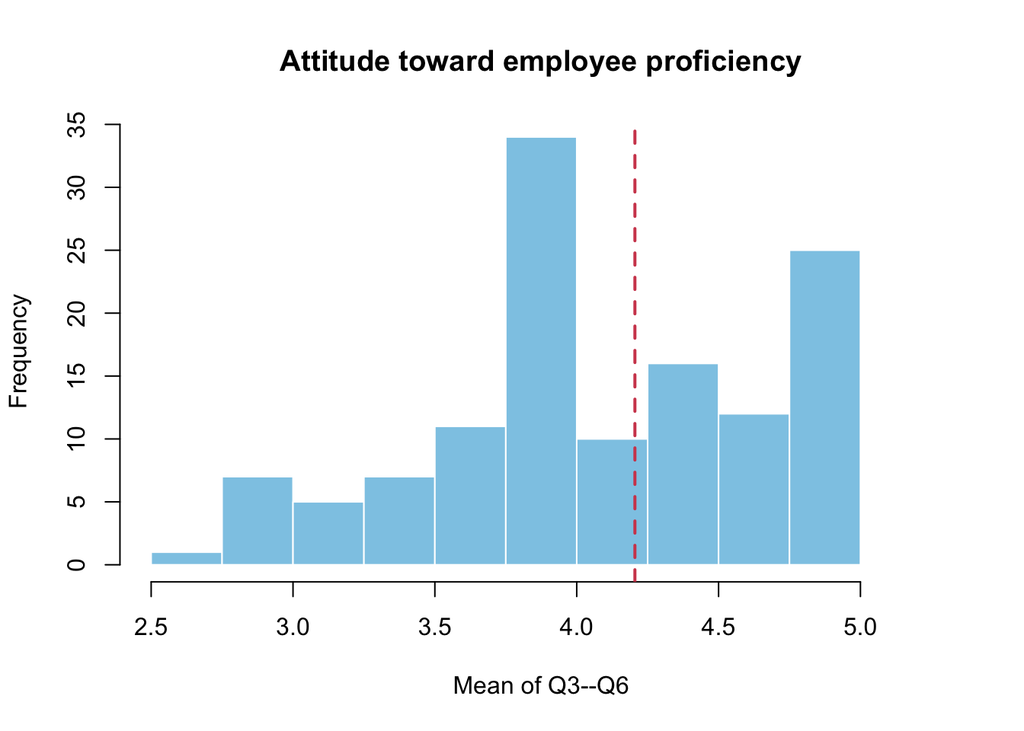

Figure 1: Distribution of the employee-proficiency composite

## One-sample t-test

The composite mean was compared with 4, the response value for **Agree**.

Table 2: One-sample t-test for employee proficiency (test value = 4)

| Mean | t value | df | p value | 95% CI lower | 95% CI upper |
| --- | --- | --- | --- | --- | --- |
| 4.205 | 3.906 | 127 | 0 | 4.101 | 4.309 |

## R3 insight

Members had a favorable view of employee proficiency. The average score was **4.21 out of 5**, slightly above the “Agree” point and statistically higher than 4 (*t*(127) = 3.91, *p* < .001). Courteousness, helpfulness, professionalism, and availability were generally rated positively.

# R6: Operational effectiveness

R6 asks: *What are members’ attitudes and beliefs about how effectively the credit union is operated?* The analysis includes statement frequency and accuracy (Q9–Q10), communication and confidentiality questions (Q11–Q12), four operational statements (Q31–Q34), and the overall rating (Q37).

## Metric-item descriptives and one-sample t-tests

For the metric items, the neutral or middle comparison value was 3. Because Q31–Q34 did not form a reliable one-dimensional scale in the previous activity, they are reported separately.

Table 3: Operational-effectiveness ratings and one-sample t-tests (test value = 3)

| Measure | N | Mean | SD | t | df | p |
| --- | --- | --- | --- | --- | --- | --- |
| Statement accuracy | 128 | 3.47 | 0.64 | 8.30 | 127 | < .001 |
| Financial information is confidential | 128 | 3.95 | 0.68 | 15.74 | 127 | < .001 |
| Loan processing is prompt | 128 | 3.72 | 0.79 | 10.25 | 127 | < .001 |
| CU meets members’ needs | 128 | 3.59 | 0.68 | 9.87 | 127 | < .001 |
| Loan application is simple | 128 | 3.46 | 0.78 | 6.66 | 127 | < .001 |
| Overall CU rating | 121 | 4.07 | 0.73 | 16.13 | 120 | < .001 |

## Categorical-item frequencies

Table 4: Response patterns for categorical operational items

| Measure | Response | N | Percent |
| --- | --- | --- | --- |
| Statement frequency | Not often enough | 29 | 22.7 |
| Statement frequency | About right | 99 | 77.3 |
| Statements are easy to understand | Yes | 125 | 97.7 |
| Statements are easy to understand | No | 3 | 2.3 |
| Account confidentiality response | Yes | 74 | 57.8 |
| Account confidentiality response | No | 32 | 25.0 |
| Account confidentiality response | Other / no opinion | 22 | 17.2 |

The categorical response distributions were not equal across categories (all goodness-of-fit tests, *p* < .001). The most visible pattern was that 77.3% viewed statement frequency as “about right,” and 97.7% said the statements were easy to understand.

## R6 insight

Overall, members viewed the credit union’s operations favorably. The overall rating averaged **4.07 out of 5**. Among Q31–Q34, confidentiality received the highest mean (3.95), while loan-application simplicity received the lowest mean (3.46). All six metric means were above the comparison value of 3 (all *p* < .001). The results are positive, but loan-application simplicity and promptness have more room for improvement than confidentiality.

# R4: Differences by residence

R4 asks whether members who live near the headquarters differ from members who live elsewhere in employee-proficiency attitudes, service awareness, and operational-effectiveness attitudes.

# R4a: Employee proficiency by residence

## Descriptive statistics

Table 5: Employee-proficiency ratings by residence

| Residence | N | Mean | SD |
| --- | --- | --- | --- |
| Headquarters area | 57 | 4.28 | 0.57 |
| Elsewhere | 71 | 4.14 | 0.61 |

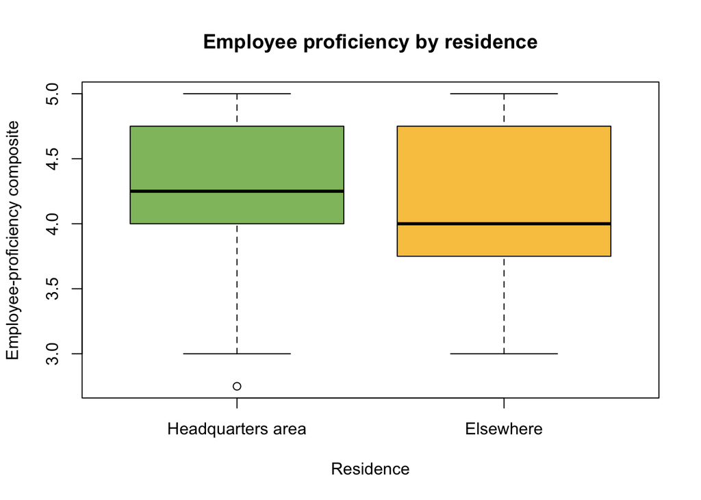

Figure 2: Employee-proficiency ratings by residence

## Independent-samples t-test

The variance test was not significant (*F*(56, 70) = 0.90, *p* = .686), so equal variances were used for this comparison.

Table 6: Independent-samples t-test for employee proficiency

| Mean difference | t | df | p value | 95% CI lower | 95% CI upper |
| --- | --- | --- | --- | --- | --- |
| -0.136 | 1.294 | 126 | 0.198 | -0.072 | 0.345 |

## R4a insight

Headquarters-area members had a slightly higher mean (4.28) than members living elsewhere (4.14), but the difference was not statistically significant (*t*(126) = 1.29, *p* = .198). Therefore, perceptions of employee proficiency appear similar across the two residence groups.

# R4b: Service awareness by residence

## Cross-tabulations and chi-square independence tests

Table 7: Service-awareness patterns and chi-square tests by residence

| Service | HQ: unaware % | Elsewhere: unaware % | Chi-square | df | p |
| --- | --- | --- | --- | --- | --- |
| Regular share account | 59.6 | 69.0 | 1.3 | 2 | 0.529 |
| Special subaccounts | 38.6 | 33.8 | 0.8 | 2 | 0.666 |
| Christmas club account | 29.8 | 35.2 | 0.4 | 2 | 0.810 |
| IRA | 28.1 | 26.8 | 0.3 | 2 | 0.849 |
| Master credit card | 17.5 | 7.0 | 3.8 | 2 | 0.150 |
| Signature loans | 7.0 | 1.4 | 2.7 | 2 | 0.265 |
| New car loans | 3.5 | 4.2 | 0.2 | 2 | 0.925 |
| Late model car loans | 14.0 | 5.6 | 2.6 | 2 | 0.269 |
| Older model car loans | 26.3 | 25.4 | 0.7 | 2 | 0.714 |
| Household goods loans | 33.3 | 25.4 | 1.0 | 2 | 0.592 |
| Recreational loans | 38.6 | 46.5 | 1.4 | 2 | 0.502 |
| Share collateralized loan | 54.4 | 53.5 | 0.0 | 2 | 0.981 |
| IRA loans | 63.2 | 59.2 | 3.3 | 2 | 0.190 |
| Line of credit loans | 0.0 | 0.0 | 0.1 | 1 | 0.748 |

## R4b insight

None of the 14 service-awareness measures had a significant association with residence (all *p* > .05). For example, regular-share-account awareness did not differ by residence ($\chi^2$(2) = 1.27, *p* = .529). Although some percentages varied slightly, there was no consistent evidence that living near the headquarters improved awareness of available services.

# R4c: Operational effectiveness by residence

## Metric outcomes: two-group t-tests

Table 8: Operational-effectiveness means and tests by residence

| Measure | HQ mean | Elsewhere mean | t | df | p |
| --- | --- | --- | --- | --- | --- |
| Statement accuracy | 3.49 | 3.45 | 0.35 | 117.53 | 0.724 |
| Financial information is confidential | 4.05 | 3.86 | 1.62 | 121.26 | 0.109 |
| Loan processing is prompt | 3.68 | 3.75 | -0.44 | 118.94 | 0.661 |
| CU meets members’ needs | 3.60 | 3.59 | 0.04 | 112.93 | 0.968 |
| Loan application is simple | 3.28 | 3.61 | -2.28 | 94.24 | 0.025 |
| Overall CU rating | 4.02 | 4.10 | -0.66 | 118.74 | 0.513 |

## Categorical outcomes: chi-square independence tests

Table 9: Categorical operational measures and chi-square tests by residence

| Measure | Chi-square | df | p |
| --- | --- | --- | --- |
| Statement frequency | 0.03 | 1 | 0.860 |
| Statements easy to understand | 0.04 | 1 | 0.847 |
| Account confidentiality response | 2.58 | 2 | 0.275 |

## R4c insight

Most operational-effectiveness measures did not differ by residence. The one exception was loan-application simplicity: members living elsewhere rated applications more positively (3.61) than headquarters-area members (3.28), and this difference was significant (*t*(94.24) = -2.28, *p* = .025). The other metric and categorical comparisons were not significant. Since many tests were performed, this single difference should be interpreted carefully.

# Overall conclusion

Members generally rated employee proficiency and credit-union operations positively. Residence was not related to employee-proficiency ratings or service awareness, and nearly all operational measures were also similar between the groups. The main practical concern is loan-application simplicity, which received a lower overall rating and was rated especially low by headquarters-area members.

# Appendix

- GitHub repository: https://github.com/WentingJiang00/IBM6500-Case31
- GitHub Pages: https://wentingjiang00.github.io/IBM6500-Case31/